# Panda_Carrillo_et_al_2024

Author

Jeanne

Published

February 4, 2026

# CUT&RUN data analysis - Figure 2

## Figure 2.A

Profile plots were generated via ucsc-genome browser by uploading bigwig files (obtained using the pre-processing scripts) with the following parameters:

- Display mode: full
- Merge method: add
- Missing data: missing is zero
- Type of graph: bar
- Track height: 80
- Data view scaling: use vertical viewing range setting (min: -0.04, max: 0.19)
- Transform function: none
- Windowing function: mean
- Smoothing window = 4
- Draw y indicator lines: OFF

## Figure 2.B, 2.C, Sup.2.B and Sup.2.C

Boxplots were generated on R using the code below, taking in input:

- Data: Table of read counts per chromosome for each sample: *read_counts_per_chrom.tsv* - Generated from samtools idxstats (1.13) output files of each sample (see pre-processing scripts) using the script *read_count_per_chrom.sh* with the following command lines:

  ```bash
  read_counts_per_chrom.sh <list_of_idxstats_files> <output_directory>
  ```

  ```bash
  bash input_files/read_counts_per_chrom.sh "data/idxstats/*idxstats.txt" "data/idxstats/"

  head "data/idxstats/read_counts_per_chrom.tsv"
  ```

  ```
  EXMC_H2AK119Ub  chr1    2202454
  EXMC_H2AK119Ub  chr10   1209526
  EXMC_H2AK119Ub  chr11   1295748
  EXMC_H2AK119Ub  chr12   1452100
  EXMC_H2AK119Ub  chr13   779624
  EXMC_H2AK119Ub  chr14   761528
  EXMC_H2AK119Ub  chr15   726550
  EXMC_H2AK119Ub  chr16   776390
  EXMC_H2AK119Ub  chr17   815808
  EXMC_H2AK119Ub  chr18   655256
  ```

- Other input file: *hg38.chrom.sizes* (containing chromosome sizes)

R code:

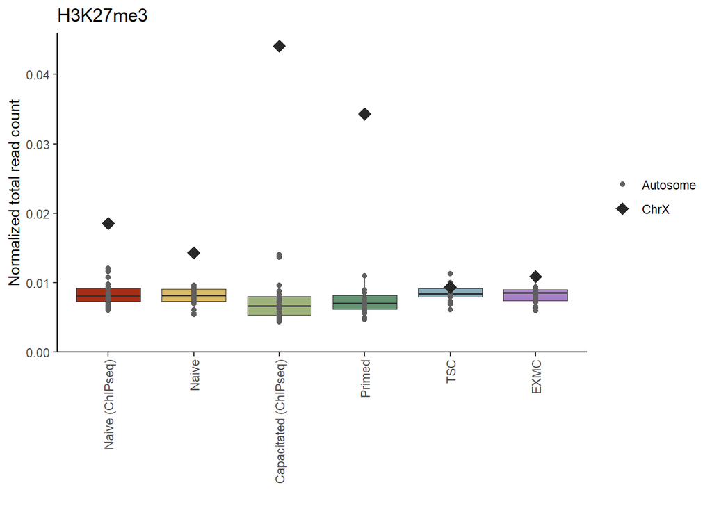

```r
library(stringr)
library(dplyr)
library(doParallel)
library(ggplot2)


###### Uploading data #####
raw_counts <- read.table(file = 'data/idxstats/read_counts_per_chrom.tsv', header = F)
colnames (raw_counts) <- c("sample", "chr", "raw_count")
# adding columns with cell types and mark
raw_counts$cellType <- unlist(lapply(str_split(raw_counts$sample,pattern="_"),function(x){x[grep('TSC|EXMC|PXGL|Primed|H9-d10|H9-d0|Rugg-Gunn-TSC-like|Okae-TSC-CT',x)]}))
raw_counts$mark <- unlist(lapply(str_split(raw_counts$sample,pattern="_"),function(x){x[grep('H3K|H2A',x)]}))

# size of each chromosome
chrom_sizes <- read.csv("input_files/hg38.chrom.sizes", sep="\t", header=F, colClasses = c("character", "numeric"))
colnames(chrom_sizes) <- c("chr", "chr_length")
rownames(chrom_sizes) <- chrom_sizes$chr
# removing chrY
raw_counts <- raw_counts[raw_counts$chr != "chrY",]


##### Calculating normalized count (by chrom length) #####
# adding a column with chrom_length, using the chrom_sizes file
raw_counts$chr_length=raw_counts$chr

for (x in rownames(chrom_sizes)){
  raw_counts$chr_length[raw_counts$chr_length == x] <- chrom_sizes[x,'chr_length']
}

#normalise counts per chrom to the size of the chrom
raw_counts$raw_count <- as.numeric(raw_counts$raw_count)
raw_counts$chr_length <- as.numeric(raw_counts$chr_length)
raw_counts$norm_count <- raw_counts$raw_count / raw_counts$chr_length


##### Final table #####
color_palette <- c("#A52F16", "#DBBB65", "#9EB27C","#659374", "#8AADBB", "#4a8ea9", "#036790", "#a980c6")

breaks_cellTypes <- c('Naive (ChIPseq)','Naive','Capacitated (ChIPseq)','Primed','TSC', 'H9-NK2 TSC', 'CT27 TSC (CUT&Tag)', 'EXMC')

# mark as a factor
counts <- raw_counts[,c("mark", "cellType","chr", "norm_count")]
counts$mark <- as.factor(counts$mark)

# adding a column with chr_type for plot legend
counts$chr_type <- counts$chr
counts$chr_type[counts$chr_type!='chrX']='Autosome'
counts$chr_type[counts$chr_type=='chrX']='ChrX'


##### Plots #####
generate_boxplot <- function(mark, ordered_cellTypes, labels_cellTypes) {
  # get data
  data <- data.frame(counts[counts$mark == mark & counts$cellType %in% ordered_cellTypes,])
  # celltype as a factor with levels (to control the order of the plots)
  data$cellType <- factor(data$cellType, levels = ordered_cellTypes, labels =  labels_cellTypes)
  # plot
  ggplot(data = data, aes(x=cellType, y=norm_count, fill=cellType)) +
    geom_boxplot(lwd = 0.3) +
  # colors
  scale_fill_manual(values = color_palette, breaks = breaks_cellTypes) +
  # adding points for each chromosome
  geom_point(data = data, aes(x=cellType, y=norm_count, shape=chr_type, size=chr_type, color=chr_type)) +
  scale_color_manual(values = c( "#606060", "#282828"))  +
  scale_shape_manual(values = c(16, 18)) +
  scale_size_manual(values = c(1.5,4)) +
  # esthetics parameters
  guides(fill= F) + #removing legend for fill=cell_type
  theme_classic() +
  theme(legend.title = element_blank(), # removing legend title
        axis.text.x = element_text(angle = 90, vjust = 0.5, hjust = 1)) +
  labs(title = mark) +
  ylab("Normalized total read count") +
  xlab('') +
  #fixing a y limit identical for each plot
  scale_y_continuous(limits = c(0,0.046), expand = c(0,0))
}


order1 <- c('H9-d0','PXGL','H9-d10', 'Primed','TSC','EXMC')
labels1 <- c('Naive (ChIPseq)','Naive','Capacitated (ChIPseq)','Primed','TSC', 'EXMC')


plot_H3K27me3 <- generate_boxplot("H3K27me3", order1, labels1)
plot_H3K27me3
```

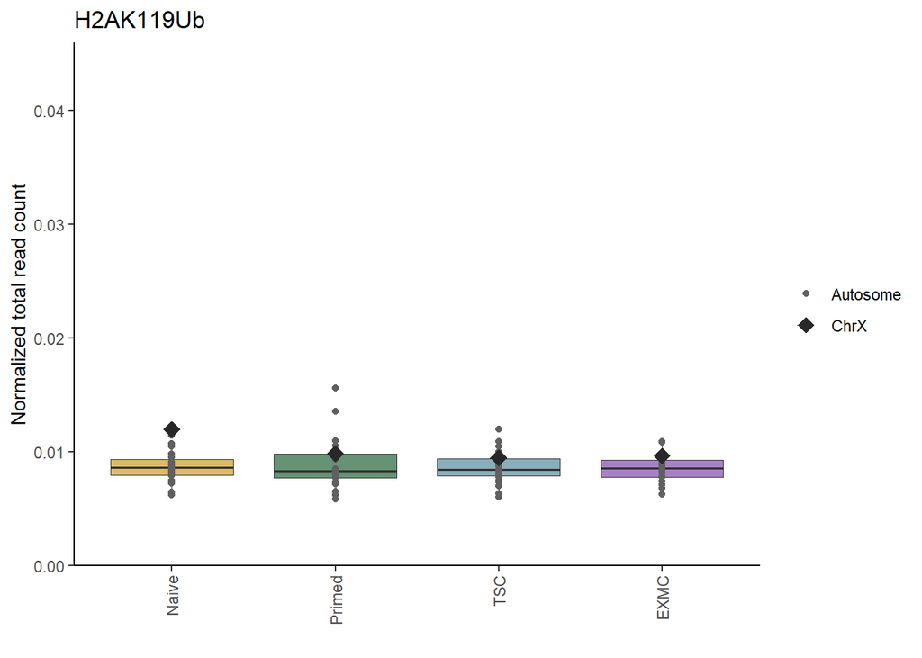

```r
plot_H2AK119Ub <- generate_boxplot("H2AK119Ub", order1, labels1)
plot_H2AK119Ub
```

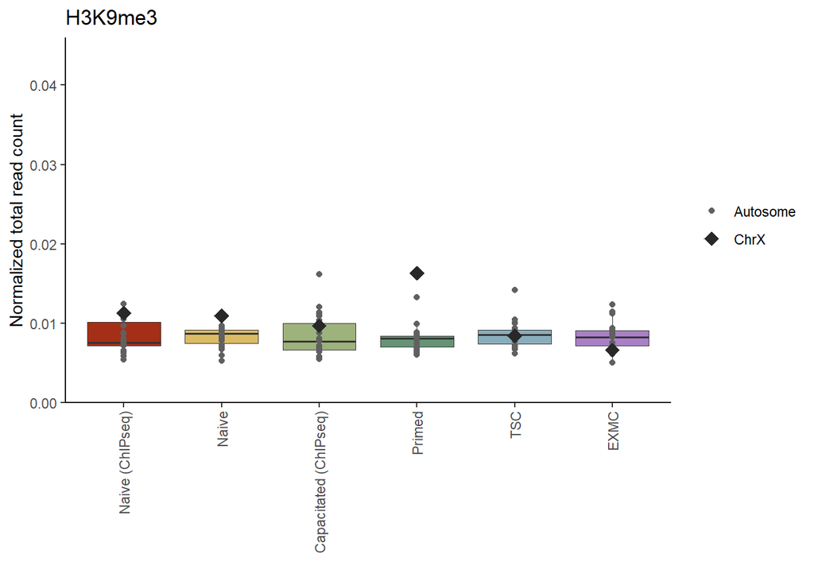

```r
plot_H3K9me3 <- generate_boxplot("H3K9me3", order1, labels1)
plot_H3K9me3
```

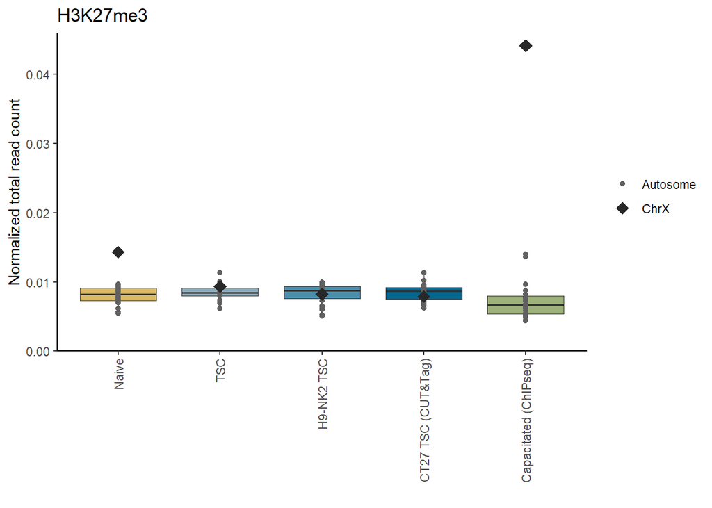

```r
order2 <- c('PXGL', 'TSC', 'Rugg-Gunn-TSC-like', 'Okae-TSC-CT', 'H9-d10')
labels2 <- c('Naive', 'TSC', 'H9-NK2 TSC', 'CT27 TSC (CUT&Tag)', 'Capacitated (ChIPseq)')


plot_H3K27me3_sup <- generate_boxplot("H3K27me3", order2, labels2)
plot_H3K27me3_sup
```

## Figure 2.D, 2.E, and Sup.2.D

Occupancy histogram were generated using the R code below, taking in input:

- Data: Macs2 output files enlarged using bedtools merge (see pre-processing scripts)
- Other input file: *hg38.chrom.sizes* (containing chromosome sizes information)

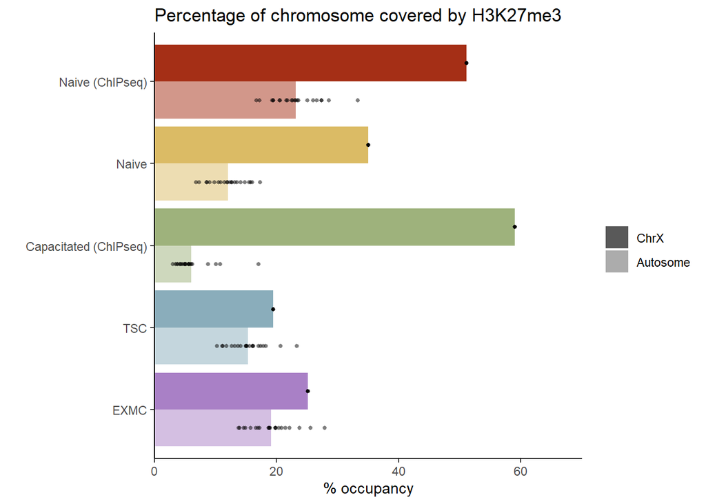

```r
#####
library(dplyr)
library(data.table)
library(stringr)
library(doParallel)
library(ggplot2)
library(ggpubr)
#####


#Uploading data : bedfiles, in a list of dataframe
bed_files=list.files(path = 'data/macs2/',pattern='enlarged')

bed_list=NULL

for(bed in bed_files){

  sample <- sub('_macs2_enlarged\\.bed','', bed) #extract sample name (replace enlarged.bed with nothing)
  # loading bed file
  bed_df <- as.data.frame(fread(file = paste0('data/macs2/', bed), header = F))
  colnames(bed_df) <- c('chr','start','end')
  # adding cell type and mark info
  bed_df$cell_type <- unlist(lapply(str_split(sample,pattern="_"),function(x){x[grep('TSC|EXMC|PXGL|H9-d10|H9-d0',x)]}))
  bed_df$mark <- unlist(lapply(str_split(sample,pattern="_"),function(x){x[grep('H3K|H2A',x)]}))
  # removing alternative contigs
  bed_df <- bed_df[!grepl('_',bed_df$chr),]
  bed_df <- bed_df[!(bed_df$chr %in% c("chrM", "chrY")),]

  #calculating each peak's length
  bed_df$start <- as.numeric(bed_df$start)
  bed_df$end <- as.numeric(bed_df$end)
  bed_df$peak_length <- bed_df$end - bed_df$start + 1

  bed_list[[sample]] <- bed_df
}

# merging all df of each sample together in one long table
all_samples_df <- bind_rows(bed_list)
all_samples_df <- all_samples_df[,c("mark", "cell_type", "chr", "peak_length")]

#calculating the sum of peak length for each chromosome
all_samples_df %>%
  group_by(mark, cell_type, chr) %>% summarize(total_peaks = sum(peak_length)) -> all_bychrom_df
all_bychrom_df <- as.data.frame(all_bychrom_df)#because it comes out as a tibble, necessary for downstream operations

# Changing the name PXGL into naive for the plot
all_bychrom_df$cell_type[all_bychrom_df$cell_type=="PXGL"] <- "Naive"

# adding info of chrom length
chrom_sizes <- read.csv("input_files/hg38.chrom.sizes", sep="\t", header=F, colClasses = c("character", "numeric"))
colnames(chrom_sizes) <- c("chr", "chr_length")
rownames(chrom_sizes) <- chrom_sizes$chr
chrom_sizes <- chrom_sizes[!grepl('_',chrom_sizes$chr),] # deleting lines corresponding to alternative contigs
chrom_sizes <- chrom_sizes[!(chrom_sizes$chr %in% c('chrM','chrY')), ] # idem for chrY and chrM
all_bychrom_df$chr_length=all_bychrom_df$chr # adding chrom_length to the table
for (x in rownames(chrom_sizes)){
  all_bychrom_df$chr_length[all_bychrom_df$chr_length==x]<-chrom_sizes[x,'chr_length']
}

# calculating coverage percent
all_bychrom_df$chr_length <- as.numeric(all_bychrom_df$chr_length)
all_bychrom_df$percent_cov <- all_bychrom_df$total_peaks / all_bychrom_df$chr_length * 100
all_bychrom_df <- all_bychrom_df[,c("mark", "cell_type", "chr", "percent_cov")]

# adding a column chr_type to allow grouping by chrX vs autosome
all_bychrom_df$chr_type <- all_bychrom_df$chr
all_bychrom_df$chr_type[all_bychrom_df$chr_type!='chrX'] <- 'Autosome'
all_bychrom_df$chr_type[all_bychrom_df$chr_type =='chrX'] <- 'ChrX'

# chromosome, cell type and chrom type as factors to control orders on the plot
all_bychrom_df$chr=factor(all_bychrom_df$chr,levels=c(paste0(rep("chr",22),seq(22)),'chrX'))
all_bychrom_df$cell_type=factor(all_bychrom_df$cell_type, levels=rev(c("H9-d0","Naive","H9-d10","TSC","EXMC")), labels = rev(c('Naive (ChIPseq)','Naive','Capacitated (ChIPseq)','TSC','EXMC')))
all_bychrom_df$chr_type=factor(all_bychrom_df$chr_type, levels=rev(c("ChrX", "Autosome")))

# cell_type factor is plotted in the opposite order so used rev(c()) to reverse the desired order,
# then used scale_fill_discrete() to reorder the legend as well


##### plot: chrX vs mean of autosomes #####
color_palette_5C <- c("#A52F16", "#DBBB65", "#9EB27C", "#8AADBB" , "#a980c6")

generate_histogram <- function(mark) {
  data <- data.frame(all_bychrom_df[all_bychrom_df$mark == mark,])
  ggplot(data = data, aes(x=cell_type, y=percent_cov, fill=cell_type, alpha=chr_type)) +
  geom_bar(stat = 'summary',position = "dodge") +
  geom_point(position = position_dodge(width = 0.9), color = 'black', shape = 16, size = 1 ) +  #can remove the black outline with stroke=NA in aes, but then cannot see points on the bar.
  scale_alpha_manual(values = c(0.5, 1)) +
  scale_fill_manual(values = color_palette_5C, breaks = c('Naive (ChIPseq)','Naive','Capacitated (ChIPseq)','TSC','EXMC')) +
  scale_y_continuous(limits = c(0,70),expand = c(0,0)) +
  ggtitle(paste0("Percentage of chromosome covered by ", mark)) +
  ylab('% occupancy') +
  xlab('') +
  guides(fill= F) +
  guides(alpha = guide_legend(override.aes = list(shape = NA), reverse = T)) +
  theme_classic() +
  theme(legend.title = element_blank()) +
  coord_flip()
}

plot_H3K27me3 <- generate_histogram(mark = "H3K27me3")
plot_H3K27me3
```

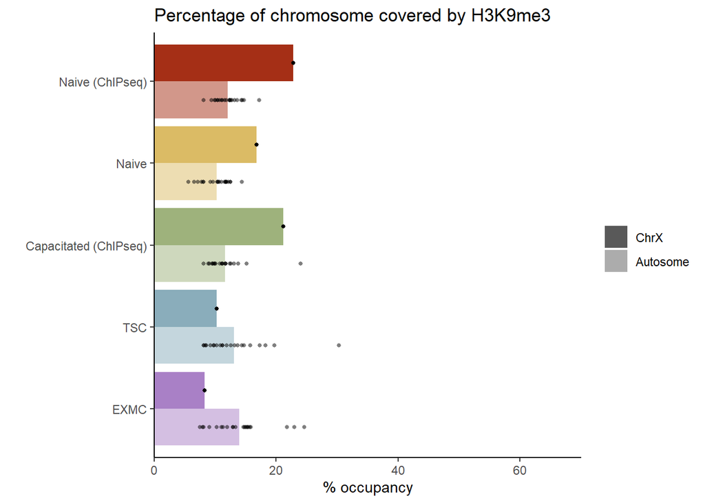

```r
plot_H3K9me3 <- generate_histogram(mark = "H3K9me3")
plot_H3K9me3
```

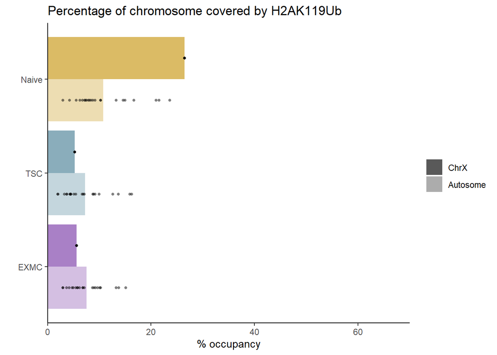

```r
plot_H2AK119Ub <- generate_histogram(mark = "H2AK119Ub")
plot_H2AK119Ub
```

## Figure 2.F and 2.G

Histograms were generated using the R code below, taking in input:

- Data: Macs2 output files enlarged using bedtools merge (see pre-processing scripts)
- Other input files:
  - Custom annotation file for each cell type (see below: Custom annotation files)
  - A control bed file containing the start and end position of all chromosomes: *hg38_allchr.bed*

### Custom annotation files

Custom annotation files were build as follow:

Homo_sapiens.GRCh38.cdna.fa.gz and Homo_sapiens.GRCh38.ncrna.fa.gz were downloaded from [ensembl.org](https://www.ensembl.org/info/data/ftp/index.html) and concatenated:

```bash
zcat Homo_sapiens.GRCh38.cdna.fa.gz Homo_sapiens.GRCh38.ncrna.fa.gz > Homo_sapiens.GRCh38.cdna.ncrna.fa.gz
```

This fasta file was used to generate an index for kallisto (0.46.0):

```bash
kallisto index -i kallisto_transcripts.idx Homo_sapiens.GRCh38.cdna.ncrna.fa.gz
```

The fasta file was also used to generate a table of all annotations:

```bash
zcat Homo_sapiens.GRCh38.cdna.ncrna.fa.gz | grep "^>" | cut -d " " -f 1,3,4 | grep -v 'scaffold' | sed 's/^>//'| sed 's/gene://' | sed 's/gene://' | sed 's/ /\t/g' > table_annot_allchr_simplified.tsv
```

kallisto (0.46.0) was run on bulk RNAseq data of Naive (Alfeghaly et al., 2023), TSC and EXMC cells (this study) using the following command line:

```bash
kallisto quant -i /shared/projects/xci/ReferenceGenomes/GRCh38/kallisto/Jeanne/kallisto_transcripts.idx -o ./ --rf-stranded --threads 8 -b 50 ../fastq/trimmed/PXGL_WT_R1_merged.fastq.gz ../fastq/trimmed/PXGL_WT_R2_merged.fastq.gz
```

The abundance.tsv output files from kallisto were processed via the following R script to filter this table to keep only one isoform per gene (the one with the highest estimated count):

```r
library(dplyr)

# Preparing kallisto data
## uploading kallisto total annot table, and outputs .tsv for each cell type
kallisto_annot_allchr <- read.table(file = "X:/ReferenceGenomes/GRCh38/kallisto/Jeanne/table_annot_allchr_simplified.tsv", header=F, sep = '\t', col.names = c("target_id", "coord", "gene_id"))
kallisto_PXGL_output <- read.table(file = "Y:/bulk_RNAseq_Charbel_PXGL/kallisto/abundance.tsv", header = T, sep = '\t')
kallisto_TSC_output <- read.table(file = "Y:/bulk_RNAseq_Bradley/kallisto/merged_rep/TSC/abundance.tsv", header = T, sep = '\t')
kallisto_EXMC_output <- read.table(file = "Y:/bulk_RNAseq_Bradley/kallisto/merged_rep/EXMC/abundance.tsv", header = T, sep = '\t')
## keep only useful columns, and reordering by gene_id
kallisto_PXGL <- merge(kallisto_annot_allchr, kallisto_PXGL_output, by = 1)[, c(2,3,1,6)]
kallisto_PXGL <- kallisto_PXGL[order(kallisto_PXGL$gene_id),]
kallisto_TSC <- merge(kallisto_annot_allchr, kallisto_TSC_output, by = 1)[, c(2,3,1,6)]
kallisto_TSC <- kallisto_TSC[order(kallisto_TSC$gene_id),]
kallisto_EXMC <- merge(kallisto_annot_allchr, kallisto_EXMC_output, by = 1)[, c(2,3,1,6)]
kallisto_EXMC <- kallisto_EXMC[order(kallisto_EXMC$gene_id),]

## keeping only "the most transcribed isoform" per gene
PXGL_most_expressed_isof.df <- kallisto_PXGL %>%
  group_by(gene_id) %>%
  slice_max(order_by = est_counts, n = 1, with_ties = F)
write.table(PXGL_most_expressed_isof.df, file = "annotation_building/PXGL_most_expressed_isof.tsv", sep = '\t', quote = F, row.names = F, col.names = F)

TSC_most_expressed_isof.df <- kallisto_TSC %>%
  group_by(gene_id) %>%
  slice_max(order_by = est_counts, n = 1, with_ties = F)
write.table(TSC_most_expressed_isof.df, file = "annotation_building/TSC_most_expressed_isof.tsv", sep = '\t', quote = F, row.names = F, col.names = F)

EXMC_most_expressed_isof.df <- kallisto_EXMC %>%
  group_by(gene_id) %>%
  slice_max(order_by = est_counts, n = 1, with_ties = F)
write.table(EXMC_most_expressed_isof.df, file = "annotation_building/EXMC_most_expressed_isof.tsv", sep = '\t', quote = F, row.names = F, col.names = F)
```

From these results, a bed file was constructed as follow to annotate gene bodies from the TSS and TES coordinates given in kallisto output, and also promoters and upstream regions define respectively as the 1kb region upstream of the TSS and the 4kb region upstream of the promoter:

```r
cat TSC_most_expressed_isof.tsv | cut -f 1,2,3 | sed 's/chromosome:GRCh38:/chr/' | sed 's/:/\t/g' | cut -f 1,2,3,5,6 | awk '{print $0 "\t" "gene_body"}' | grep -v 'chrMT' | awk 'BEGIN{FS=OFS="\t"} {print $1, $2 - 1000, $2, $4, $5, "promoter"} {print $0}' | awk 'BEGIN{FS=OFS="\t"} $6=="promoter"{print $1, $2 - 4000 , $2, $4, $5, "upstream_1-5kb" } {print $0}' | sort -k1,1V -k2,2n -k3,3n > TSC_most_expr_isof_annot_promot_upstream.bed
cat EXMC_most_expressed_isof.tsv | cut -f 1,2,3 | sed 's/chromosome:GRCh38:/chr/' | sed 's/:/\t/g' | cut -f 1,2,3,5,6 | awk '{print $0 "\t" "gene_body"}' | grep -v 'chrMT' | awk 'BEGIN{FS=OFS="\t"} {print $1, $2 - 1000, $2, $4, $5, "promoter"} {print $0}' | awk 'BEGIN{FS=OFS="\t"} $6=="promoter"{print $1, $2 - 4000 , $2, $4, $5, "upstream_1-5kb" } {print $0}' | sort -k1,1V -k2,2n -k3,3n > EXMC_most_expr_isof_annot_promot_upstream.bed
cat PXGL_most_expressed_isof.tsv | cut -f 1,2,3 | sed 's/chromosome:GRCh38:/chr/' | sed 's/:/\t/g' | cut -f 1,2,3,5,6 | awk '{print $0 "\t" "gene_body"}' | grep -v 'chrMT' | awk 'BEGIN{FS=OFS="\t"} {print $1, $2 - 1000, $2, $4, $5, "promoter"} {print $0}' | awk 'BEGIN{FS=OFS="\t"} $6=="promoter"{print $1, $2 - 4000 , $2, $4, $5, "upstream_1-5kb" } {print $0}' | sort -k1,1V -k2,2n -k3,3n > PXGL_most_expr_isof_annot_promot_upstream.bed
```

Enhancers data were downloaded from the [FANTOM5 consortium website](https://fantom.gsc.riken.jp/5/datafiles/reprocessed/hg38_v9/extra/enhancer/), reformatted and concatenated with the annotation files build above:

```r
zcat F5.hg38.enhancers.bed.gz | sort -k1,1V -k2,2n -k3,3n | cut -f 1,2,3 | awk 'BEGIN{id=0} {id +=1 ; print $0 "\t" "NA\tenhancer_" id "\tenhancer"}' > F5.hg38.enhancers.allchr.reformatted.bed
cat F5.hg38.enhancers.allchr.reformatted.bed TSC_most_expr_isof_annot_promot_upstream.bed | sort -k1,1V -k2,2n -k3,3n > TSC_most_expr_isof_annot_promot_upstream_enhancers.bed
cat F5.hg38.enhancers.allchr.reformatted.bed EXMC_most_expr_isof_annot_promot_upstream.bed | sort -k1,1V -k2,2n -k3,3n > EXMC_most_expr_isof_annot_promot_upstream_enhancers.bed
cat F5.hg38.enhancers.allchr.reformatted.bed PXGL_most_expr_isof_annot_promot_upstream.bed | sort -k1,1V -k2,2n -k3,3n > PXGL_most_expr_isof_annot_promot_upstream_enhancers.bed
```

Intergenic regions were constructed using bedtools substract (2.30.0), defined as all regions that were not annotated as gene body, promoter, upstream or enhancer:

```bash
bedtools subtract -a hg38_allchr.bed -b TSC_most_expr_isof_annot_promot_upstream_enhancers.bed | cut -f 1,2,3,4 | awk '{print $1, $2, $3, "\tNA\tNA\tintergenic"}' | cat - TSC_most_expr_isof_annot_promot_upstream_enhancers.bed | sort -k1,1V -k2,2n -k3,3n > TSC_genes_annot_from_kallisto_with-enhancers.bed
bedtools subtract -a hg38_allchr.bed -b EXMC_most_expr_isof_annot_promot_upstream_enhancers.bed | cut -f 1,2,3,4 | awk '{print $1, $2, $3, "\tNA\tNA\tintergenic"}' | cat - EXMC_most_expr_isof_annot_promot_upstream_enhancers.bed | sort -k1,1V -k2,2n -k3,3n > EXMC_genes_annot_from_kallisto_with-enhancers.bed
bedtools subtract -a hg38_allchr.bed -b PXGL_most_expr_isof_annot_promot_upstream_enhancers.bed | cut -f 1,2,3,4 | awk '{print $1, $2, $3, "\tNA\tNA\tintergenic"}' | cat - PXGL_most_expr_isof_annot_promot_upstream_enhancers.bed | sort -k1,1V -k2,2n -k3,3n > PXGL_genes_annot_from_kallisto_with-enhancers.bed
```

Finally, these bed files were reformatted to fit the *read_annotations* function requirement of *annotatr* (1.28.0) on R.

```bash
cat TSC_genes_annot_from_kallisto_with-enhancers.bed | awk '{ print $1 "\t" $2 "\t" $3 "\t" $4 "\t" "0" "\t" "." "\t" $5 "\t" $4 "\t" "test" "\t" $6}' > TSC_genes_annot_from_kallisto_with-enhancers_for-annotatr.bed
cat EXMC_genes_annot_from_kallisto_with-enhancers.bed | awk '{ print $1 "\t" $2 "\t" $3 "\t" $4 "\t" "0" "\t" "." "\t" $5 "\t" $4 "\t" "test" "\t" $6}' > EXMC_genes_annot_from_kallisto_with-enhancers_for-annotatr.bed
cat PXGL_genes_annot_from_kallisto_with-enhancers.bed | awk '{ print $1 "\t" $2 "\t" $3 "\t" $4 "\t" "0" "\t" "." "\t" $5 "\t" $4 "\t" "test" "\t" $6}' > PXGL_genes_annot_from_kallisto_with-enhancers_for-annotatr.bed
```

### Histograms

R code:

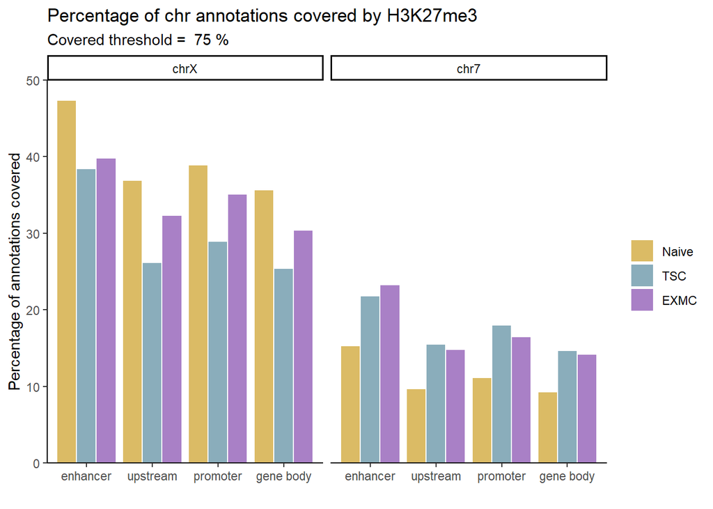

```r
# R version used : 4.3.2
library(annotatr) #v.1.28.0
library(GenomicRanges)
library(dplyr)
library(tidyr)
library(stringr)
library(doParallel) # for %do%
library(ggplot2)


##### Uploading the different peak datasets: #####

## peaks from macs2 enlarged with bedtools merge
peaks_H3K27me3_PXGL.gr <- read_regions(con = "data/macs2/PXGL_H3K27me3_macs2_enlarged.bed" , genome = 'hg38', format = 'bed')
peaks_H3K27me3_TSC.gr <- read_regions(con = "data/macs2/TSC_H3K27me3_macs2_enlarged.bed" , genome = 'hg38', format = 'bed')
peaks_H3K27me3_EXMC.gr <- read_regions(con = "data/macs2/EXMC_H3K27me3_macs2_enlarged.bed" , genome = 'hg38', format = 'bed')
peaks_H2AK119Ub_PXGL.gr <- read_regions(con = "data/macs2/PXGL_H2AK119Ub_macs2_enlarged.bed" , genome = 'hg38', format = 'bed')
peaks_H2AK119Ub_TSC.gr <- read_regions(con = "data/macs2/TSC_H2AK119Ub_macs2_enlarged.bed" , genome = 'hg38', format = 'bed')
peaks_H2AK119Ub_EXMC.gr <- read_regions(con = "data/macs2/EXMC_H2AK119Ub_macs2_enlarged.bed" , genome = 'hg38', format = 'bed')

## control chrX and chr7 : making copies to be annotated with different annotation set (one for each cell_type) as control
whole_chr_PXGL.gr = read_regions(con = "input_files/hg38_allchr.bed" , genome = 'hg38', format = 'bed')
whole_chr_TSC.gr = read_regions(con = "input_files/hg38_allchr.bed" , genome = 'hg38', format = 'bed')
whole_chr_EXMC.gr = read_regions(con = "input_files/hg38_allchr.bed" , genome = 'hg38', format = 'bed')

peaksets_list <- GRangesList(whole_chr_PXGL.gr,
                             whole_chr_TSC.gr,
                             whole_chr_EXMC.gr,
                         peaks_H3K27me3_PXGL.gr,
                         peaks_H3K27me3_TSC.gr,
                         peaks_H3K27me3_EXMC.gr,
                         peaks_H2AK119Ub_PXGL.gr,
                         peaks_H2AK119Ub_TSC.gr,
                         peaks_H2AK119Ub_EXMC.gr
                         )

# order them for the plot
names_peaksets <- c("whole_chr_PXGL",
                    "whole_chr_TSC",
                    "whole_chr_EXMC",
                    "H3K27me3_PXGL",
                    "H3K27me3_TSC",
                    "H3K27me3_EXMC",
                    "H2AK119Ub_PXGL",
                    "H2AK119Ub_TSC",
                    "H2AK119Ub_EXMC")

names(peaksets_list) <- names_peaksets
peaksets_list <- as.list(peaksets_list)


##### Annotation #####

# preparing annotation set
## uploading custom annotations made from kallisto
read_annotations(con = "input_files/TSC_genes_annot_from_kallisto_with-enhancers_for-annotatr.bed", genome='hg38', name = 'kallisto_annot_TSC', format = 'bed', extraCols = c( tx_id='character', gene_id='character', type="character", symbol="character" ))
read_annotations(con = "input_files/EXMC_genes_annot_from_kallisto_with-enhancers_for-annotatr.bed", genome='hg38', name = 'kallisto_annot_EXMC', format = 'bed', extraCols = c( tx_id='character', gene_id='character', type="character", symbol="character" ))
read_annotations(con = "input_files/PXGL_genes_annot_from_kallisto_with-enhancers_for-annotatr.bed", genome='hg38', name = 'kallisto_annot_PXGL', format = 'bed', extraCols = c( tx_id='character', gene_id='character', type="character", symbol="character" ))
#print(annotatr_cache$get('hg38_custom_kallisto_annot_TSC'))

# build annotation
annots_custom_TSC <- c ('hg38_custom_kallisto_annot_TSC')
annots_custom_EXMC <- c ('hg38_custom_kallisto_annot_EXMC')
annots_custom_PXGL <- c ('hg38_custom_kallisto_annot_PXGL')

annotations_TSC <- build_annotations(genome = 'hg38', annotations = annots_custom_TSC )
annotations_EXMC <- build_annotations(genome = 'hg38', annotations = annots_custom_EXMC )
annotations_PXGL <- build_annotations(genome = 'hg38', annotations = annots_custom_PXGL )

annotation_list <- list( PXGL = annotations_PXGL,
                         TSC = annotations_TSC,
                         EXMC = annotations_EXMC)

# annotating peaksets
## functions
annotate <- function(peaks_gr, annotations) {
  annotated_gr = annotate_regions(
    regions = peaks_gr,
    annotations = annotations,
    ignore.strand = TRUE,
    quiet = FALSE
  )
  return(data.frame(annotated_gr))
}

calculate_overlap <- function(data) {
  data <- data %>%
    mutate(intersection_start = ifelse(data$annot.start >= data$start, data$annot.start, data$start)) %>%
    mutate(intersection_end = ifelse(data$annot.end <= data$end, data$annot.end, data$end))

  data$overlapping_width <- data$intersection_end - data$intersection_start + 1
  data$overlapping_percent <- data$overlapping_width/data$annot.width * 100

  return(data)
}

## analysis
annotated_peaksets <- list()

for (i in 1:length(peaksets_list)) { #loop through each table=peakset
  gr <- peaksets_list[[i]]
  peakset_name <- names(peaksets_list)[i]
  # find the appropriate annotation set to use based on the name
  if (grepl('TSC', peakset_name, ignore.case = TRUE)) {
    annotation_to_use <- annotations_TSC
    cell_type <- 'TSC'
  } else if (grepl('PXGL', peakset_name, ignore.case = TRUE)) {
    annotation_to_use <- annotations_PXGL
    cell_type <- 'PXGL'
  } else if (grepl('EXMC', peakset_name, ignore.case = TRUE)) {
    annotation_to_use <- annotations_EXMC
    cell_type <- 'EXMC'
  } else {
    warning("Unknown cell type for peakset: ", peakset_name, ". PXGL annotation used.")
    annotation_to_use <- annotations_PXGL
    cell_type <- peakset_name
  }
  # Annotate
  annotated_df <- annotate(gr, annotation_to_use)
  # Calculate overlap length
  annotated_df <- calculate_overlap(annotated_df)
  # exchange annot.symbol and annot.type because didn't manage to load custom annots properly
  annot_set_id <- annotated_df$annot.type
  annotated_df$annot.type <- annotated_df$annot.symbol
  annotated_df$annot.symbol <- annot_set_id
  # add columns with the peakset info to allow making groups during plotting
  ## peakset name
  annotated_df$peakset <- peakset_name
  ## mark
  if (grepl('H3K27me3', peakset_name, ignore.case = T)) {
    annotated_df$mark <- "H3K27me3"
  } else if (grepl('H2AK119Ub', peakset_name, ignore.case = T)) {
    annotated_df$mark <- "H2AK119Ub"
  } else {
    annotated_df$mark <- "None"
  }
  ## cell type
  annotated_df$cell_type <- cell_type
  if (grepl('whole', peakset_name, ignore.case = T)) { # correctly name the controls whose cell types are currently annotated EXMC TSC etc which is incorrect
    annotated_df$cell_type <- peakset_name
  } else if (grepl('DA', peakset_name, ignore.case = T)) {
    annotated_df$cell_type <- peakset_name
  }
  # Filtering to keep only chrX and chr7
  annotated_df <- annotated_df[annotated_df$seqnames %in% c('chr7', 'chrX'),]
  # Store result in the list
  annotated_peaksets[[i]] <- annotated_df
}

# renaming the df in the list
names(annotated_peaksets) <- names_peaksets


##### plot histogram #####

palette_paper_3C <- c( "#DBBB65", "#8AADBB" , "#a980c6")


calculate_percentage <- function(data, gp_cell_type, control_df) {
  if (gp_cell_type == 'PXGL') {
    ctrl_gp <- filter(control_df, cell_type == 'whole_chr_PXGL')
  } else if (gp_cell_type == 'TSC') {
    ctrl_gp <- filter(control_df, cell_type == 'whole_chr_TSC')
  } else if (gp_cell_type == 'EXMC') {
    ctrl_gp <- filter(control_df, cell_type == 'whole_chr_EXMC')
  }

  ctrl_gp <- ctrl_gp[,c('seqnames', 'annot.type', 'counts_annot')]

  data %>%
    left_join(ctrl_gp, by = c("seqnames", "annot.type"), suffix = c("", "_control")) %>%
    mutate(percentage_of_chr = counts_annot / counts_annot_control * 100)
}


generate_histogram <- function(annotated_peaksets_list, mark, threshold_covered_percentage = 75, color_palette) {
  # preparing summary table
  annot_count_tables <- list() # initiating empty list
  for (i in 1:length(annotated_peaksets_list)) {
    # counting nb of covered annotation, for each annot.type, for each peakset
    count_table <- annotated_peaksets_list[[i]] %>%
      filter(overlapping_percent > threshold_covered_percentage) %>%
      group_by(mark, cell_type, seqnames, annot.type) %>%
      summarise(counts_annot = n()) # counting the number of annotation falling in each category
    annot_count_tables[[i]] <- count_table # store the summary table in the list initiated above
  }
  # merging the list of df in one long df
  annot_counts_alldata <- bind_rows(annot_count_tables)
  # removing all 'intergenic' data because unused here
  annot_counts_alldata <- annot_counts_alldata[!(annot_counts_alldata$annot.type == 'intergenic'),]
  # separating the long table in two, one ctrl, one with target data
  control_df <- annot_counts_alldata[ annot_counts_alldata$mark == 'None', ]
  target_df <- annot_counts_alldata[ annot_counts_alldata$mark == mark, ]
  # calculate percentage of control chr:
  histogram_table <- target_df %>%
    group_by(cell_type) %>%
    group_modify(~ calculate_percentage(.,.y, control_df))
  # variables as factor to control order in the plot
  histogram_table$cell_type <- factor(x = histogram_table$cell_type, levels = c("PXGL", "TSC", "EXMC"), labels = c("Naive", "TSC", "EXMC"))
  histogram_table$annot.type <- factor(x = histogram_table$annot.type, levels = c("intergenic", "enhancer", "upstream_1-5kb", "promoter", "gene_body"), label = c("intergenic", "enhancer", "upstream", "promoter", "gene body"))
  histogram_table$seqnames <- factor(x = histogram_table$seqnames, levels = c( 'chrX', 'chr7'))
  # plot
  ggplot(data = histogram_table, aes(x = annot.type, y = percentage_of_chr, fill = cell_type)) +
    # bars displaying the mean of each replicates
    geom_bar(stat = 'summary',position = "dodge", color='white') +
    scale_fill_manual(values = color_palette) +
    # points for each replicates
    labs(
      title = paste("Percentage of chr annotations covered by", mark),
      subtitle = paste("Covered threshold = ", threshold_covered_percentage, "%"),
      x = "",
      y = 'Percentage of annotations covered'
    ) +
    facet_grid(~ seqnames, scales = "free_x", space = "free_x") +
    scale_y_continuous(limits = c(0,50), expand = c(0,0)) +
    theme_classic() +
    theme(legend.title = element_blank())
}



plot_hist_H3K27 <- generate_histogram(annotated_peaksets, "H3K27me3", 75, palette_paper_3C)
plot_hist_H3K27
```

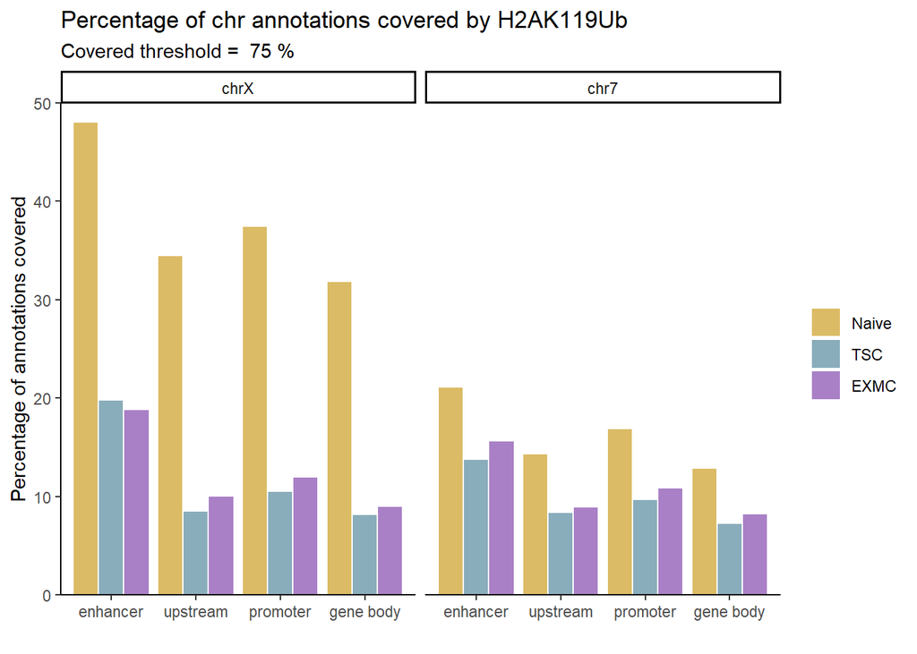

```r
plot_hist_H2AUb <- generate_histogram(annotated_peaksets, "H2AK119Ub", 75, palette_paper_3C)
plot_hist_H2AUb
```

## Figure 2.J

MeDseq histogram was obtained using the R code below, taking in input:

- Data: MeDseq bigwig files, generated by bamCoverage () (see pre-processing scripts)
- Other input files:
  - *sample_annot_med_seq_human.txt* (metadata)
  - A bed file listing CpG islands: *cpgIslandExt.hg38.bed*

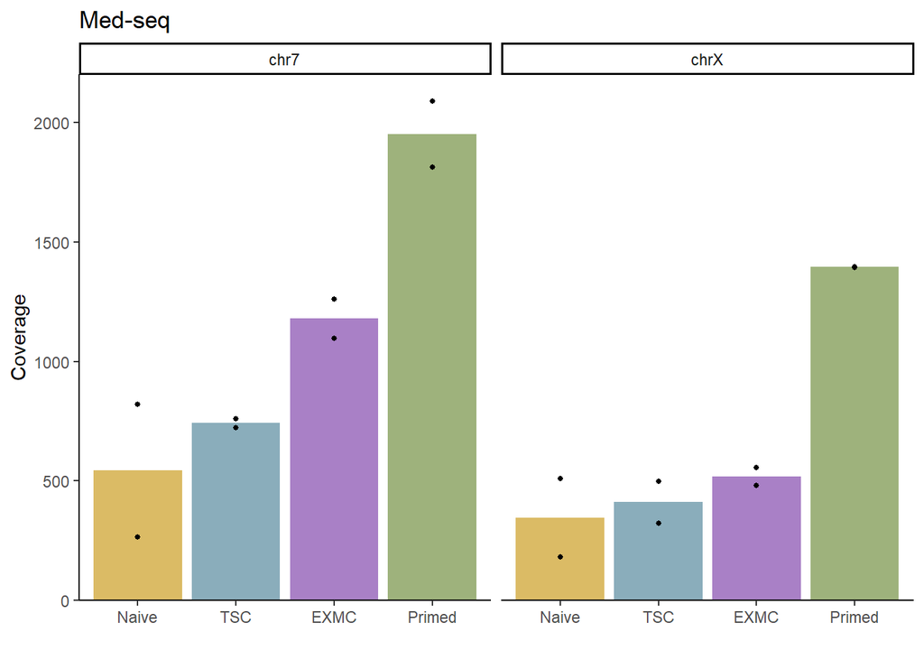

```r
source("https://gitlab.univ-nantes.fr/E114424Z/veneR/-/raw/master/loadFun.R")

# .libPaths(c("/shared/projects/xci/r_packages/","/shared/software/conda/envs/r-4.1.1/lib/R/library/"))
# ALSO: make it expandable/deployable to IPOP-UP cluster

# NB: for reproducibility, prefer: if requires(package) -> BiocManager::install(package) -> library(package)

# BiocManager::install('EnhancedVolcano')
library(GenomicRanges)
library(plyranges)
library(monocle3)
library(SingleCellExperiment)
library(dplyr)
library(tidyr)
library(ggplot2)
library(Matrix)
library(stringr)
library(BiocManager)
library(devtools)
library(pcaMethods)
library(data.table)
library(parallel)
library(DESeq2)
library(ggpubr)
library(tidyverse)
library(EnhancedVolcano)
library(rstatix)
library(biomaRt)
library(gtools)
library(parallel)
library(statebins)
library(sva)
library(wesanderson)
#library(kableExtra)
library(ScaledMatrix)
library(DelayedArray)
library(BiocSingular)
library(uwot)
library(speedglm)
library(plotly)
library(doParallel)
library(circlize)
library(ComplexHeatmap)
library(WGCNA)
library(waveslim)
library(wavelets)
# library(rtracklayer)

timeNow<-function(x=NULL, y=NULL, m=NULL, d=NULL , h=NULL, min=NULL,ymd_h_m=NULL){x=date();
date=unlist(str_split(pattern = "-", Sys.Date()))
time=unlist(str_split(pattern = ":",unlist(str_split(pattern=" ",Sys.time()))[2]))
return(paste(c(date,time), collapse = "_"))
}


sample_annot=fastRead("input_files/sample_annot_med_seq_human.txt", header=T, sep="\t",as.matrix = F)
sample_annot$sample_id=rn(sample_annot)
sample_annot$cell_type_condition=paste(sep="_",sample_annot$cell_type,sample_annot$condition)



cpg_bed =  read.table("input_files/cpgIslandExt.hg38.bed")
cpg_bed=cpg_bed[cpg_bed$V1%in%c(paste0("chr",c(seq(22),"X"))),]


cpg_bed <- GRanges(seqnames = cpg_bed$V1,
            ranges = IRanges(start = cpg_bed$V2,
                             end = cpg_bed$V3),length=cpg_bed$V5,sites=cpg_bed$V6)


bw=as.list(list.files(path = "data/medseq_bigwig/", pattern = "_no_norm_no_dedduped.bw"))

# findOverlaps cpg_bed and prom/enhancer/repetitive_elements

bw_list=sapply(bw, function(x) {read_bigwig(paste0("data/medseq_bigwig/",x),overlap_ranges=cpg_bed)})
names(bw_list)=sub("_no_norm.*","",unlist(bw))
bw_list=bw_list[rn(sample_annot)]

bw_list_df=lapply(bw_list,function(x){

  x=as.data.frame(x)
  x=x[x$score>0,]
  x=x[,c("seqnames","start","end","score")]
  rownames_x=paste(sep = "_",x$seqnames,x$start,x$end)
  x=as.data.frame(x[,'score'])
  x$rownames_x=rownames_x
  return(x)

})

bw_list_df %>% reduce(full_join, by = "rownames_x") -> bw_df

rownames(bw_df)=bw_df$rownames_x
bw_df$rownames_x=NULL

bw_df[is.na(bw_df)]<-0

colnames(bw_df)=names(bw_list_df)

bw_df=bw_df[,rn(sample_annot)]

mra_samples=apply(bw_df,2,function(x){
  dwt=waveslim::mra(x,J = 8, method = "modwt",boundary = "reflection")
  dwt$D1[dwt$D1<0]<-0
  dwt$D2[dwt$D2<0]<-0
  dwt$D3[dwt$D3<0]<-0
  dwt$D4[dwt$D4<0]<-0
  dwt$D5[dwt$D5<0]<-0
  dwt$D6[dwt$D6<0]<-0
  dwt$D7[dwt$D7<0]<-0
  dwt$D8[dwt$D8<0]<-0

  names(dwt$D1)=rn(bw_df)
  names(dwt$D2)=rn(bw_df)
  names(dwt$D3)=rn(bw_df)
  names(dwt$D4)=rn(bw_df)
  names(dwt$D5)=rn(bw_df)
  names(dwt$D6)=rn(bw_df)
  names(dwt$D7)=rn(bw_df)
  names(dwt$D8)=rn(bw_df)


  return(dwt)
})

#rn(sample_annot)

#head(mra_samples[["naive-dox-clone1"]]$D1[order(mra_samples[["naive-dox-clone1"]]$D1,decreasing = T)])
#head(mra_samples[["naive-dox-clone1"]]$D8[order(mra_samples[["naive-dox-clone1"]]$D8,decreasing = T)])

#grep('chr10_3067601_3067620',names(mra_samples[["naive-dox-clone1"]]$D1))

subset_naive_dox_clone1=mra_samples[["naive-dox-clone1"]]$D1[grepl("chr10",names(mra_samples[["naive-dox-clone1"]]$D1))]

bw_df_corrected=log2(bw_df+1)

# Estimating background threshold
# ggplot()+
#   geom_point(aes(x=rn(bw_df)[11000:13000],y=log2(bw_df[,"naive-dox-clone1"][11000:13000]+1)))+
#   geom_hline(yintercept = 4.8)

bw_df_corrected$'naive-dox-clone1'[bw_df_corrected$'naive-dox-clone1'<4.8]=0

# ggplot()+
#   geom_point(aes(x=rn(bw_df)[11000:13000],y=log2(bw_df[,"naive-dox-clone2"][11000:13000]+1)))+
#   geom_hline(yintercept = 4)

bw_df_corrected$'naive-dox-clone2'[bw_df_corrected$'naive-dox-clone2'<4]=0

# ggplot()+
#   geom_point(aes(x=rn(bw_df)[11000:13000],y=log2(bw_df[,"naive-dox-clone3"][11000:13000]+1)))+
#   geom_hline(yintercept = 5)

bw_df_corrected$'naive-dox-clone3'[bw_df_corrected$'naive-dox-clone3'<5]=0

# ggplot()+
#   geom_point(aes(x=rn(bw_df)[11000:13000],y=log2(bw_df[,"naive-WT-dox-clone4"][11000:13000]+1)))+
#   geom_hline(yintercept = 4.8)

bw_df_corrected$'naive-WT-dox-clone4'[bw_df_corrected$'naive-WT-dox-clone4'<4.8]=0

# ggplot()+
#   geom_point(aes(x=rn(bw_df)[11000:13000],y=log2(bw_df[,"naive-WT-dox-clone5"][11000:13000]+1)))+
#   geom_hline(yintercept = 4.5)

bw_df_corrected$'naive-WT-dox-clone5'[bw_df_corrected$'naive-WT-dox-clone5'<4.5]=0

# ggplot()+
#   geom_point(aes(x=rn(bw_df)[11000:13000],y=log2(bw_df[,"naive-untreated-clone1"][11000:13000]+1)))+
#   geom_hline(yintercept = 4)

bw_df_corrected$'naive-untreated-clone1'[bw_df_corrected$'naive-untreated-clone1'<4]=0

# ggplot()+
#   geom_point(aes(x=rn(bw_df)[11000:13000],y=log2(bw_df[,"naive-untreated-clone2"][11000:13000]+1)))+
#   geom_hline(yintercept = 5.2)

bw_df_corrected$'naive-untreated-clone2'[bw_df_corrected$'naive-untreated-clone2'<5.2]=0

# ggplot()+
#   geom_point(aes(x=rn(bw_df)[11000:13000],y=log2(bw_df[,"naive-untreated-clone3"][11000:13000]+1)))+
#   geom_hline(yintercept = 3.8)

bw_df_corrected$'naive-untreated-clone3'[bw_df_corrected$'naive-untreated-clone3'<3.8]=0

# ggplot()+
#   geom_point(aes(x=rn(bw_df)[11000:13000],y=log2(bw_df[,"naive-WT-untreated-clone4"][11000:13000]+1)))+
#   geom_hline(yintercept = 4)

bw_df_corrected$'naive-WT-untreated-clone4'[bw_df_corrected$'naive-WT-untreated-clone4'<4]=0

# ggplot()+
#   geom_point(aes(x=rn(bw_df)[11000:13000],y=log2(bw_df[,"naive-WT-untreated-clone5"][11000:13000]+1)))+
#   geom_hline(yintercept = 4)

bw_df_corrected$'naive-WT-untreated-clone5'[bw_df_corrected$'naive-WT-untreated-clone5'<4]=0

# ggplot()+
#   geom_point(aes(x=rn(bw_df)[11000:13000],y=log2(bw_df[,"Naive-WT-rep1"][11000:13000]+1)))+
#   geom_hline(yintercept = 4)

bw_df_corrected$'Naive-WT-rep1'[bw_df_corrected$'Naive-WT-rep1'<4]=0

# ggplot()+
#   geom_point(aes(x=rn(bw_df)[11000:13000],y=log2(bw_df[,"Naive-WT-rep2"][11000:13000]+1)))+
#   geom_hline(yintercept = 4.3)

bw_df_corrected$'Naive-WT-rep2'[bw_df_corrected$'Naive-WT-rep2'<4.3]=0

# ggplot()+
#   geom_point(aes(x=rn(bw_df)[11000:13000],y=log2(bw_df[,"Primed-WT-rep1"][11000:13000]+1)))+
#   geom_hline(yintercept = 4)

bw_df_corrected$'Primed-WT-rep1'[bw_df_corrected$'Primed-WT-rep1'<4]=0

# ggplot()+
#   geom_point(aes(x=rn(bw_df)[11000:13000],y=log2(bw_df[,"Primed-WT-rep2"][11000:13000]+1)))+
#   geom_hline(yintercept = 3.5)

bw_df_corrected$'Primed-WT-rep2'[bw_df_corrected$'Primed-WT-rep2'<3.5]=0

# ggplot()+
#   geom_point(aes(x=rn(bw_df)[11000:13000],y=log2(bw_df[,"TSC-WT-rep1"][11000:13000]+1)))+
#   geom_hline(yintercept = 4)

bw_df_corrected$'TSC-WT-rep1'[bw_df_corrected$'TSC-WT-rep1'<4]=0

# ggplot()+
#   geom_point(aes(x=rn(bw_df)[11000:13000],y=log2(bw_df[,"TSC-WT-rep2"][11000:13000]+1)))+
#   geom_hline(yintercept = 3.5)

bw_df_corrected$'TSC-WT-rep2'[bw_df_corrected$'TSC-WT-rep2'<3.5]=0

# ggplot()+
#   geom_point(aes(x=rn(bw_df)[11000:13000],y=log2(bw_df[,"EXMC-WT-rep1"][11000:13000]+1)))+
#   geom_hline(yintercept = 4.5)

bw_df_corrected$'EXMC-WT-rep1'[bw_df_corrected$'EXMC-WT-rep1'<4.5]=0

# ggplot()+
#   geom_point(aes(x=rn(bw_df)[11000:13000],y=log2(bw_df[,"EXMC-WT-rep2"][11000:13000]+1)))+
#   geom_hline(yintercept = 4)

bw_df_corrected$'EXMC-WT-rep2'[bw_df_corrected$'EXMC-WT-rep2'<4]=0


# Confirm peak threshold on regions covered in naive untreated
#head(mra_samples[["naive-untreated-clone1"]]$D1[order(mra_samples[["naive-untreated-clone1"]]$D1,decreasing = T)])
#grep('chr8_144125881_144125900',names(mra_samples[["naive-untreated-clone1"]]$D1))

# ggplot()+
#   geom_point(aes(x=rn(bw_df)[640000:650000],y=log2(bw_df[,"naive-untreated-clone1"][640000:650000]+1)))+
#   geom_hline(yintercept = 4)

# bw_df_corrected$'naive-untreated-clone1'[bw_df_corrected$'naive-untreated-clone1'<4.8]=0

# ggplot()+
#   geom_point(aes(x=rn(bw_df)[640000:650000],y=log2(bw_df[,"naive-untreated-clone2"][640000:650000]+1)))+
#   geom_hline(yintercept = 5.2)

# head(mra_samples[["TSC-WT-rep2"]]$D1[order(mra_samples[["TSC-WT-rep2"]]$D1,decreasing = T)])
# grep('chr20_26209601_26209620',names(mra_samples[["TSC-WT-rep2"]]$D1))

# ggplot()+
#   geom_point(aes(x=rn(bw_df)[88000:90000],y=log2(bw_df[,"TSC-WT-rep2"][88000:90000]+1)))+
#   geom_hline(yintercept = 3.5)

bw_df_corrected$'TSC-WT-rep2'[bw_df_corrected$'TSC-WT-rep2'<3.5]=0

#colSums(bw_df_corrected)

bw_df_corrected$chr=sub("_.*","",rn(bw_df_corrected))

bw_df_corrected%>%
  group_by(chr) %>%
  summarise(across(everything(), list(sum))) -> bw_df_corrected_sum

#colnames(bw_df_corrected_sum)=sub("_1.*","",colnames(bw_df_corrected_sum))

bw_df_corrected_sum %>%
  pivot_longer(!c(chr), names_to = "sample", values_to = "count") -> bw_df_corrected_sum_longer

bw_df_corrected_sum_longer$cell_type=rep(rep(sample_annot$cell_type,each=1),nrow(bw_df_corrected_sum))
bw_df_corrected_sum_longer$condition=rep(rep(sample_annot$condition,each=1),nrow(bw_df_corrected_sum))
bw_df_corrected_sum_longer$cell_type_condition=rep(rep(sample_annot$cell_type_condition,each=1),nrow(bw_df_corrected_sum))
bw_df_corrected_sum_longer$cell_type_condition=factor(bw_df_corrected_sum_longer$cell_type_condition,levels=c("naive_xist_untreated","naive_xist_dox","naive_wt_untreated","naive_wt_dox","NAIVE_wt","EXMC_wt","TSC_wt","PRIMED_wt"))

bw_df_corrected_sum_longer %>%
  group_by(chr,cell_type_condition) %>%
  # summarise(count=mean(count)) %>%
  mutate(mean=mean(count),sd=sd(count),chr=factor(chr,levels=paste0("chr",c(seq(22),"X"))),cell_type_condition=factor(cell_type_condition,levels=c("naive_xist_untreated","naive_xist_dox","naive_wt_untreated","naive_wt_dox","NAIVE_wt","EXMC_wt","TSC_wt","PRIMED_wt"))) %>%
  as.data.frame() -> df_plot

# To download data table
#write.table(df_plot, file = "MeDseq_data_table_for_barplot.tsv", sep = "\t", col.names = T, row.names = F)

# To upload data table
#df_plot <- read.table("MeDseq_data_table_for_barplot.tsv", sep = "\t", header = T)

# Plot
list_cell_type <- c("NAIVE", "TSC", "EXMC", "PRIMED")
labels_cell_type <- c("Naive", "TSC", "EXMC", "Primed")

color_palette <- c("#DBBB65", "#8AADBB" , "#a980c6", "#9EB27C" )

df_plot <- df_plot %>%
  filter(cell_type %in% list_cell_type) %>%
  filter(condition == "wt") %>%
  filter(chr %in% c("chr7", "chrX")) # change here for chrX only plot
df_plot$cell_type <- factor(df_plot$cell_type, levels = list_cell_type, labels = labels_cell_type)

ggplot(data = df_plot, aes(x = cell_type, y = count, fill = cell_type)) +
  geom_bar(stat = 'summary', show.legend = F) +
  scale_fill_manual(values = color_palette) +
  geom_point(position = position_dodge(width = 0.9), shape = 16, color = 'black', size = 1, show.legend = F) +
  theme_classic() +
  scale_y_continuous(limits = c(0,2200), expand = c(0,0)) + # for chrX only, ylim = 1500
  labs(title = "Med-seq", y = "Coverage", x = "" ) + #for chrX only: , subtitle = "ChrX"
  facet_grid(col=vars(chr))
```

## Figure Sup.2.A

Correlation heatmap was obtained using the R code below, taking in input:

- Data: **regions.bed* files generated by mosdepth (0.3.3) (see pre-processing scripts)
- Other input files: *sample_sheet_PXGL.csv* and *sample_sheet_TSC-EXMC.csv* (metadata)

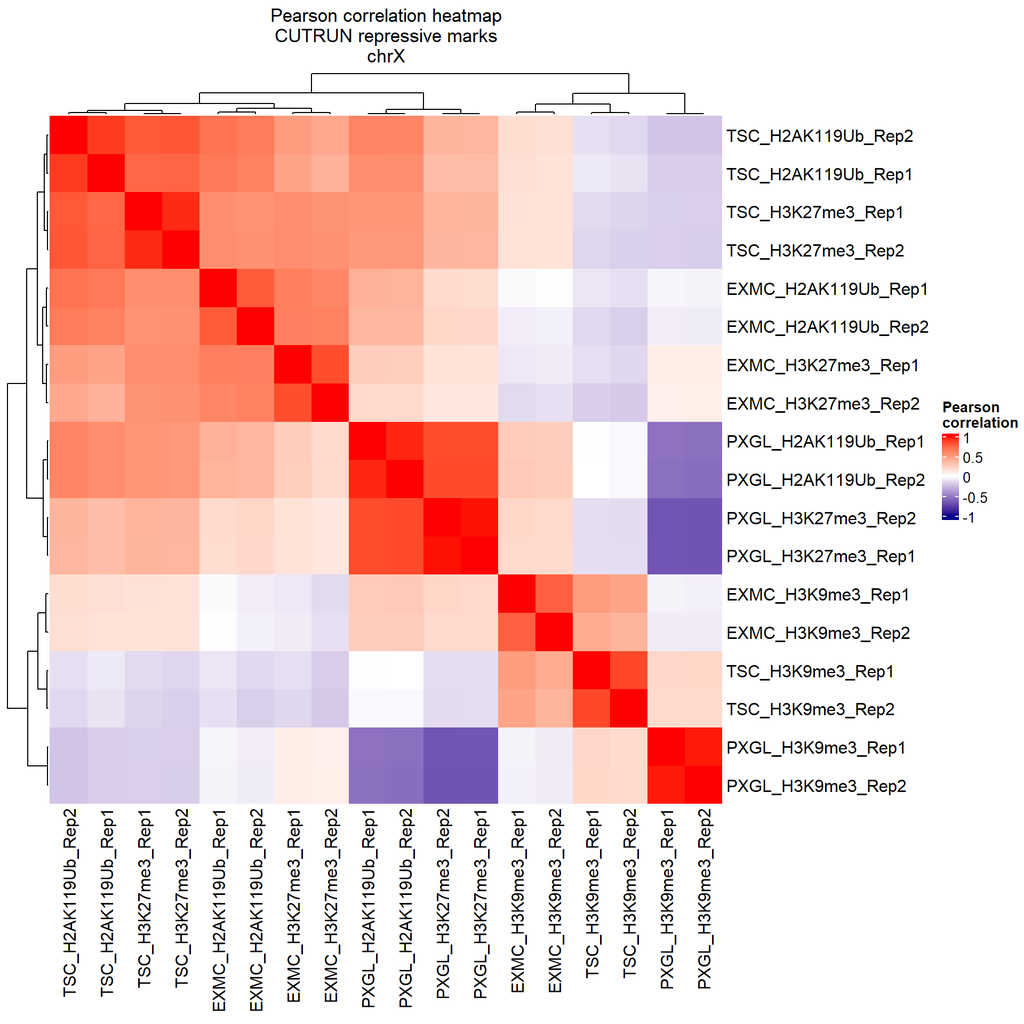

```r
library(doParallel)
library(BiocParallel)
library(dplyr)
library(ggplot2)
library(ggrepel)
library(stringr)
library(sva)
library(ggpubr)
library(rstatix)
library(data.table)
library(tidyr)
library(circlize)
library(ComplexHeatmap)


###### functions ######

getMostVariableGenes4<-function(counts,minCount=0.01,plot=TRUE,returnPlot=FALSE){
  counts<-counts[rowMeans(counts)>minCount,]
  dispTable<-data.frame(mu=rowMeans(counts),var=apply(counts,1,var),row.names =rownames(counts))
  dispTable$cv2 <- dispTable$var / dispTable$mu^2
  sumNullvariance<-sum(dispTable$cv2 <= 0)
  if(sumNullvariance>0){
    warning(paste0(sumNullvariance, " have null variance and will be removed"))
    dispTable<-dispTable[dispTable$cv2 > 0,]
  }
  fit<-loess(cv2~mu,data = log10(dispTable[,c("mu","cv2")]))
  dispTable$residuals<-fit$residuals
  dispTable$residuals2<-dispTable$residuals^2
  dispTable$fitted<-10^fit$fitted
  if(plot){
    require(ggplot2)
    require(ggrepel)
    require(circlize)
    g<-ggplot(dispTable,aes(x=mu,y=cv2,label=rownames(dispTable),fill=residuals))+
      geom_point(stroke=1/8,colour = "black",shape=21)+geom_line(aes(y=fitted),color="red",linewidth=1.5)+
      scale_x_log10()+scale_y_log10()
    if(returnPlot){
      return(g)
    }else{
      print(g)
    }
  }
  dispTable
}

qplotDensity<-function(x,printGraph=TRUE,...){
  require(ggplot2)
  if(class(x)=="data.frame" | class(x)=="list") x<-unlist(x)
  if(class(x)=="matrix") x<-as.vector(x)
  g<-qplot(x,geom="density",...)
  if(printGraph){
    print(g)
  }else{
    g
  }
}

autoGparFontSizeMatrix<-function(n,...){ #Calcule automatiquement la taille de police selon le nombre de colonnes ou lignes (empirique)
  n=max(n,50)
  n=min(n,1000)
  return(gpar(fontsize=1/n*600,...))
}

cl <- makeCluster(10)  # Use 10 cores
registerDoParallel(cl)




##### Sample sheet preparation: adding columns with celltype, mark, replicate #####
sample_annot_tsc_exmc <- read.csv("input_files/sample_sheet_TSC-EXMC.csv", header=T)
sample_annot_pxgl <- read.csv("input_files/sample_sheet_PXGL.csv", header = F)
colnames(sample_annot_pxgl) <- colnames(sample_annot_tsc_exmc)

#merging both sample_annot files
sample_annot <- rbind(sample_annot_tsc_exmc, sample_annot_pxgl)

rownames(sample_annot) <- sample_annot$Sample_ID
sample_annot$cellType <- unlist(lapply(str_split(sample_annot$Sample_Name,pattern="_"),function(x){x[grep('TSC|EXMC|PXGL',x)]}))

sample_annot$mark <- unlist(lapply(str_split(sample_annot$Sample_Name,pattern="_"),function(x){x[grep('H3K|H2A|IGG',x)]}))
sample_annot$replicate <- sub('.*_','',sample_annot$Sample_Name)
sample_annot$target <- sample_annot$mark
sample_annot$target[sample_annot$target!='IGG'] <- 'target'


bed_files <- list.files(path = 'data/bed/', pattern='regions')

bed_list <- NULL

for(bed in bed_files){

  sample <- sub('\\.regions.*','',bed)

  bed_list[[sample]] <- as.data.frame(fread(file = paste0('data/bed/',bed), header = F))
  colnames(bed_list[[sample]]) <- c('chr','start','end',sample)
  bed_list[[sample]] <- bed_list[[sample]][!grepl('_',bed_list[[sample]]$chr),] # Filters rows to remove those where the 'chr' column contains underscores ('_') (alt contigs)
  bed_list[[sample]][,sample] <- (bed_list[[sample]][,sample])/sum((bed_list[[sample]][,sample]))*1e6 # normalization

}


bed_list <- bed_list[rownames(sample_annot)]

bed_list_chrX <- lapply(bed_list,function(x){
  x <- x[x$chr=='chrX',]
  x$feature <- paste(sep="_",x$chr,x$start,x$end)
  x <- x[,c(5,4)]
  return(x)
})

bed_chrX_df <- do.call('cbind',bed_list_chrX)
rownames(bed_chrX_df) <- bed_chrX_df[,1]
bed_chrX_df <- bed_chrX_df[,!grepl("feature",colnames(bed_chrX_df))]


sample_annot_target <- sample_annot[!grepl("IGG",sample_annot$mark),]


##### Filter out region where it is equal to 0 for every sample ######
colnames(bed_chrX_df) <- rownames(sample_annot)
bed_chrX_df_expressed <- bed_chrX_df[, rownames(sample_annot_target)]
rownames(bed_chrX_df_expressed) <- rownames(bed_chrX_df)
bed_chrX_df_expressed <- bed_chrX_df_expressed[rowSums(bed_chrX_df_expressed) > 0, ]
colnames(bed_chrX_df_expressed) <- rownames(sample_annot_target)


######## select most variable bins for each histone mark #########
bed_chrX_df_expressed$rownames <- rownames(bed_chrX_df_expressed)
bed_chrX_df_expressed_wide <- bed_chrX_df_expressed

# Reorganising the table in long format not wide
bed_chrX_df_expressed %>%
  tidyr::pivot_longer( !rownames , names_to = "sample", values_to = "coverage") -> bed_chrX_df_expressed # reorganise tableau en longueur

# Adding a column with the histone mark using the sample name and the sample sheet.
bed_chrX_df_expressed$mark <- bed_chrX_df_expressed$sample
bed_chrX_df_expressed$mark <- unlist(sapply(bed_chrX_df_expressed$mark,function(x){sample_annot[x,'mark']}))

# group by histone mark
bed_chrX_df_expressed %>%
  group_by(mark) %>%
  group_split()->bed_chrX_expr_mark_list

names(bed_chrX_expr_mark_list) <- unlist(lapply(bed_chrX_expr_mark_list,function(x){unique(x$mark)}))

bed_chrX_expr_mark_list <- lapply(bed_chrX_expr_mark_list,function(x){x[,c('rownames','sample','coverage')]})

rownames(bed_chrX_expr_mark_list) <- bed_chrX_expr_mark_list$rownames

#pivot_wider the dataframe from each histone mark to have the different samples in columns and all the regions in rows
bed_chrX_expr_mark_list <- lapply(bed_chrX_expr_mark_list,function(x){

  x %>%
    tidyr::pivot_wider(names_from = sample, values_from = coverage) %>%
    as.data.frame() -> x

})

# Calculates the 500 (can choose other nb) most variable regions=bins for each mark, returns a list of 3 lists (each length=500)
var_bins_mark <- lapply(bed_chrX_expr_mark_list,function(x){

  rownames(x) <- x$rownames
  x$rownames <- NULL
  x <- x[rowSums(x)>20,]
  variableBins <- getMostVariableGenes4(x, plot = FALSE)
  thres<- 0.25
  #qplotDensity(variableBins$residuals, printGraph = T)+geom_vline(xintercept = thres)
  variableBinsNames <- head(rownames(variableBins)[order(variableBins$residuals,decreasing = T)],500)
  #length(variableBinsNames)
  return(variableBinsNames)

})

# merge the list of 3 lists in one big list of 1500 bins name (some are the same, Not unique)
var_bins <- unlist(var_bins_mark)

# filter the bed_chrX_df_expressed for the selected most var bins, without the mark column
bed_chrX_df_expressed$mark <- NULL
bed_chrX_df_expressed_var_bins <- bed_chrX_df_expressed[bed_chrX_df_expressed$rownames %in% var_bins, ]


bed_chrX_df_expressed_var_bins %>%
  tidyr::pivot_wider(names_from = "sample", values_from = "coverage") -> bed_chrX_df_expressed_var_bins

regions <- bed_chrX_df_expressed_var_bins$rownames
bed_chrX_df_expressed_var_bins$rownames <- NULL
rownames(bed_chrX_df_expressed_var_bins) <- regions
colnames(bed_chrX_df_expressed_var_bins) <- sample_annot_target$Sample_Name
bed_chrX_df_expressed_var_bins <- as.data.frame(bed_chrX_df_expressed_var_bins)


##### Plot  #####
cor_matrix <- cor(log2(bed_chrX_df_expressed_var_bins+1)) #cor by default uses Pearson

colorScale <- colorRamp2(c(-1, 0, 1), c("#00008B", "white", "#FF0000"))

options(repr.plot.width =10, repr.plot.height =30)

hmPearson <- Heatmap(cor_matrix,
                  col = colorScale,clustering_method_columns = "ward.D2",
                  clustering_method_rows = "ward.D2",
                  show_row_names = T,
                  show_column_names = T,
                  row_names_gp = autoGparFontSizeMatrix(nrow(cor(log2(bed_chrX_df_expressed_var_bins+1)))),
                  name = "Pearson\ncorrelation",
                  column_title = "Pearson correlation heatmap\nCUTRUN repressive marks\nchrX")

hmPearson
```